# KNN渠道价值风险评估

YANG_HONG

2025-04-10

# 数据准备

清洗数据后选择关键指标， 要将渠道分群为“高价值低风险”、“低价值高风险”等类别， 需要结合 价值指标（如销量、活跃度）和 风险指标（如逾期率、经营状态）

###价值维度（Value）有 1.销量贡献 近1年销量、历史销量、周销量、近3月预审通过量 （反映渠道的销售能力及业务规模） 2.活跃度、活跃频次、近3月预审通过进件量 （高频活跃的渠道可能更稳定且价值高） 3.地域等级、市场等级 （高等级地区通常带来更高价值）

###风险维度（Risk） 1. 逾期风险 近1年M1+逾期率、历史M1+逾期率、近1年逾期量、历史逾期量 2. 主体经营状态（如“关闭”可能代表高风险） 3. 初始生效日期、合作到期日期（计算合作时长，长期合作可能更稳定） 4. 主营品牌（某些品牌或车源可能风险更高） 5. 渠道二级科目（不同渠道属性，风险不同，比如4S店一般来说风险低于二手车店面）

```r
setwd("D:/Chrome_download")

channels <- read_xlsx("渠道管理列表.xlsx")

channels <- channels %>%
    rename_at('负责员工(金融顾问)', ~'负责员工') %>%
    mutate(负责员工 = fn_drop_parentheses(负责员工),
           业务上级 = fn_drop_parentheses(业务上级),
           初始生效日期 = ymd(初始生效日期),
           渠道关停日期 = ymd(渠道关停日期)
    )


channels_tidyed <- channels %>%
  select(近1年销量, 历史销量, 周销量, 近3月预审通过量, 活跃度, 活跃频次, 近3月预审通过进件量,
         活跃度, 活跃频次, 近3月预审通过进件量, 地域等级, 市场等级, 店面评级,
         '近1年M1+逾期率', '历史M1+逾期率', 近1年逾期量, 历史逾期量, 主体经营状态, 初始生效日期, 主营品牌, 渠道二级科目
         ) %>%
  mutate(
    across(
      c(近1年销量, 历史销量, 周销量, 近3月预审通过量, 近3月预审通过进件量, 近1年逾期量, 历史逾期量, 活跃频次),
      as.numeric)) %>%
  mutate(
    across(
      c(`近1年M1+逾期率`, `历史M1+逾期率`),
      ~ parse_number(., "%") / 100  )# 自动解析百分比
  ) %>%
  #填补空值,再归一化
  mutate(近1年销量 = rescale(ifelse(is.na(近1年销量), 0, 近1年销量)),
         历史销量 = rescale(ifelse(is.na(历史销量), 0, 历史销量)),
         周销量 = rescale(ifelse(is.na(周销量), 0, 周销量)),
         近3月预审通过量 = rescale(ifelse(is.na(近3月预审通过量), 0, 近3月预审通过量)),
         活跃频次 = rescale(ifelse(is.na(活跃频次), 0, 活跃频次)),
         近3月预审通过进件量 = rescale(ifelse(is.na(近3月预审通过进件量), 0, 近3月预审通过进件量)),
         `近1年M1+逾期率` = rescale(ifelse(is.na(`近1年M1+逾期率`), 0, `近1年M1+逾期率`)),
         `历史M1+逾期率` = rescale(ifelse(is.na(`历史M1+逾期率`), 0, `历史M1+逾期率`)),
         近1年逾期量 = rescale(ifelse(is.na(近1年逾期量), 0, 近1年逾期量)),
         历史逾期量 = rescale(ifelse(is.na(历史逾期量), 0, 历史逾期量)),
         ) %>%
  #处理分类变量，factor
  mutate(
         店面评级 = as.factor(ifelse(is.na(店面评级), "nul", 店面评级)),
         活跃度 = as.factor(ifelse(is.na(活跃度), "nul", 活跃度)),
         地域等级 = as.factor(ifelse(is.na(地域等级), "nul", 地域等级)),
         市场等级 = as.factor(ifelse(is.na(市场等级), "nul" , 市场等级)),
         主体经营状态 = as.factor(ifelse(is.na(主体经营状态), "注销", 主体经营状态)),
         #主营品牌 = as.factor(ifelse(is.na(主营品牌), "nul", 主营品牌)),
         渠道二级科目 = as.factor(ifelse(is.na(渠道二级科目), "nul", 渠道二级科目))
         ) %>%
  mutate(合作天数 = as.numeric(today() - 初始生效日期)) %>%
  mutate(合作天数 = rescale(ifelse(is.na(合作天数), 0, 合作天数))) %>%
  select(-初始生效日期, -主营品牌) %>%
  data.frame()




glimpse(channels_tidyed)
```

```
## Rows: 1,602
## Columns: 17
## $ 近1年销量           <dbl> 0.000000000, 0.000000000, 0.000000000, 0.000000000…
## $ 历史销量            <dbl> 0.0000000000, 0.0000000000, 0.0000000000, 0.009353…
## $ 周销量              <dbl> 0.0000000, 0.0000000, 0.0000000, 0.0000000, 0.0000…
## $ 近3月预审通过量     <dbl> 0.00000000, 0.00000000, 0.00000000, 0.00000000, 0.…
## $ 活跃度              <fct> N3+, N3-, N3-, Y24, N3-, Y12, Y24+, N3+, Y1, Y12, …
## $ 活跃频次            <dbl> 0.00000000, 0.00000000, 0.00000000, 0.00000000, 0.…
## $ 近3月预审通过进件量 <dbl> 0.00000000, 0.00000000, 0.00000000, 0.00000000, 0.…
## $ 地域等级            <fct> C1, U1, U1, U2, U2, C1, U1, U1, U1, U1, U1, U1, C1…
## $ 市场等级            <fct> CA, UA, UA, UD, UD, CA, UA, UA, UA, UA, UA, UA, CA…
## $ 店面评级            <fct> D, D, D, D, D, D, D, D, D, D, B, D, C, D, D, D, C,…
## $ 近1年M1.逾期率      <dbl> 0.0000, 0.0000, 0.0000, 0.0000, 0.0000, 0.0000, 0.…
## $ 历史M1.逾期率       <dbl> 0.0000, 0.0000, 0.0000, 0.0000, 0.0000, 0.0000, 0.…
## $ 近1年逾期量         <dbl> 0.0, 0.0, 0.0, 0.0, 0.0, 0.0, 0.0, 0.0, 0.0, 0.0, …
## $ 历史逾期量          <dbl> 0.00000000, 0.00000000, 0.00000000, 0.00000000, 0.…
## $ 主体经营状态        <fct> 存续, 存续, 存续, 存续, 存续, 存续, 存续, 存续, 存续, 存续, 存续, 存续, 存续…
## $ 渠道二级科目        <fct> 直营自拓4S店, 厂商4S店, 厂商4S店, 直营自拓4S店, 厂商4S店, 厂商4S店, 厂商4S…
## $ 合作天数            <dbl> 1.0000000000, 0.0000000000, 0.0000000000, 0.173656…
```

```r
str(channels_tidyed)
```

```
## 'data.frame':    1602 obs. of  17 variables:
##  $ 近1年销量          : num  0 0 0 0 0 ...
##  $ 历史销量           : num  0 0 0 0.00935 0 ...
##  $ 周销量             : num  0 0 0 0 0 ...
##  $ 近3月预审通过量    : num  0 0 0 0 0 ...
##  $ 活跃度             : Factor w/ 9 levels "N3-","N3+","nul",..: 2 1 1 6 1 5 7 2 4 5 ...
##  $ 活跃频次           : num  0 0 0 0 0 ...
##  $ 近3月预审通过进件量: num  0 0 0 0 0 0 0 0 0 0 ...
##  $ 地域等级           : Factor w/ 5 levels "C1","C2","M",..: 1 4 4 5 5 1 4 4 4 4 ...
##  $ 市场等级           : Factor w/ 9 levels "CA","CB","CC",..: 1 6 6 9 9 1 6 6 6 6 ...
##  $ 店面评级           : Factor w/ 6 levels "A","A+","B","C",..: 5 5 5 5 5 5 5 5 5 5 ...
##  $ 近1年M1.逾期率     : num  0 0 0 0 0 0 0 0 0 0 ...
##  $ 历史M1.逾期率      : num  0 0 0 0 0 0 0 0 0 0 ...
##  $ 近1年逾期量        : num  0 0 0 0 0 0 0 0 0 0 ...
##  $ 历史逾期量         : num  0 0 0 0 0 0 0 0 0 0 ...
##  $ 主体经营状态       : Factor w/ 4 levels "存续","开业",..: 1 1 1 1 1 1 1 1 1 1 ...
##  $ 渠道二级科目       : Factor w/ 11 levels "厂商4S店","分公司直营店",..: 10 1 1 10 1 1 1 10 11 11 ...
##  $ 合作天数           : num  1 0 0 0.173657 0.000178 ...
```

```r
summary(channels_tidyed)
```

```
##    近1年销量         历史销量            周销量         近3月预审通过量
##  Min.   :0.0000   Min.   :0.000000   Min.   :0.000000   Min.   :0.00000
##  1st Qu.:0.0000   1st Qu.:0.000000   1st Qu.:0.000000   1st Qu.:0.00000
##  Median :0.0000   Median :0.001701   Median :0.000000   Median :0.00000
##  Mean   :0.0154   Mean   :0.022418   Mean   :0.008115   Mean   :0.01436
##  3rd Qu.:0.0000   3rd Qu.:0.012755   3rd Qu.:0.000000   3rd Qu.:0.00000
##  Max.   :1.0000   Max.   :1.000000   Max.   :1.000000   Max.   :1.00000
##
##      活跃度       活跃频次       近3月预审通过进件量 地域等级    市场等级
##  Y24+   :511   Min.   :0.00000   Min.   :0.00000     C1:276   UA     :547
##  N3+    :498   1st Qu.:0.00000   1st Qu.:0.00000     C2:248   CA     :305
##  Y1     :134   Median :0.00000   Median :0.00000     M :  1   UD     :243
##  Y24    :126   Mean   :0.09192   Mean   :0.01594     U1:511   UB     :181
##  Y3     :115   3rd Qu.:0.00000   3rd Qu.:0.00000     U2:566   CC     :107
##  Y12    : 86   Max.   :1.00000   Max.   :1.00000              UC     :106
##  (Other):132                                                  (Other):113
##  店面评级   近1年M1.逾期率     历史M1.逾期率      近1年逾期量
##  A  :   4   Min.   :0.000000   Min.   :0.00000   Min.   :0.000000
##  A+ :   2   1st Qu.:0.000000   1st Qu.:0.00000   1st Qu.:0.000000
##  B  :  29   Median :0.000000   Median :0.00000   Median :0.000000
##  C  : 205   Mean   :0.002398   Mean   :0.01322   Mean   :0.009051
##  D  :1313   3rd Qu.:0.000000   3rd Qu.:0.00000   3rd Qu.:0.000000
##  nul:  49   Max.   :1.000000   Max.   :1.00000   Max.   :1.000000
##
##    历史逾期量       主体经营状态       渠道二级科目    合作天数
##  Min.   :0.000000   存续:1555    直营二手车  :457   Min.   :0.0000
##  1st Qu.:0.000000   开业:   1    直营综合店  :421   1st Qu.:0.1478
##  Median :0.000000   在业:   5    厂商4S店    :408   Median :0.2481
##  Mean   :0.009651   注销:  41    直营自拓4S店:252   Mean   :0.2860
##  3rd Qu.:0.000000                全国代理商  : 22   3rd Qu.:0.4277
##  Max.   :1.000000                区域代理商  : 15   Max.   :1.0000
##                                  (Other)     : 27
```

```r
sum(is.na(channels_tidyed))
```

```
## [1] 0
```

```r
#不平衡的问题----

##转为as.numeric
channels_tidyed <- as.data.frame(lapply(channels_tidyed, as.numeric))
## 确保因变量是因子类型
#channels_tidyed$店面评级 <- as.factor(channels_tidyed$店面评级)


sample_index <- sample(nrow(channels_tidyed), round(nrow(channels_tidyed)* 0.75), replace = F)
channels_train <- channels_tidyed[sample_index, ]
channels_test <- channels_tidyed[-sample_index, ]

#对比原来三个数据集不平衡的情况
round(prop.table(table(select(channels_tidyed, 店面评级), exclude = NULL)), 4) * 100
```

```
## 店面评级
##     1     2     3     4     5     6
##  0.25  0.12  1.81 12.80 81.96  3.06
```

```r
round(prop.table(table(select(channels_train, 店面评级), exclude = NULL)), 4) * 100
```

```
## 店面评级
##     1     2     3     4     5     6
##  0.08  0.17  1.58 11.98 83.78  2.41
```

```r
round(prop.table(table(select(channels_test, 店面评级), exclude = NULL)), 4) * 100
```

```
## 店面评级
##     1     3     4     5     6
##  0.75  2.50 15.25 76.50  5.00
```

分布不平衡，需要调整平衡

```r
#解决不平衡的问题----
set.seed(1234)

# 确保因变量是因子
channels_train$店面评级 <- as.factor(channels_train$店面评级)

# 检查类别分布
table(channels_train$店面评级)
```

```
##
##    1    2    3    4    5    6
##    1    2   19  144 1007   29
```

```r
# 检查是否有缺失值
sum(is.na(channels_train))
```

```
## [1] 0
```

```r
# 移除或填补缺失值
channels_train <- channels_train[complete.cases(channels_train), ]


#___选择合适的值

# 检查类别分布
class_counts <- table(channels_train$店面评级)
min_class_size <- min(class_counts)  # 最小类别样本数
max_class_size <- max(class_counts)  # 最大类别样本数

# 如果目标是完全平衡
perc.over <- ceiling((max_class_size / min_class_size - 1) * 100)
perc.under <- ceiling((max_class_size / (min_class_size * (1 + perc.over / 100))) * 100)

# 打印参数
print(paste("perc.over:", perc.over))
```

```
## [1] "perc.over: 100600"
```

```r
print(paste("perc.under:", perc.under))
```

```
## [1] "perc.under: 100"
```

```r
#——————选择合适的值




# 使用 SMOTE 平衡数据--------------------------------------------------------
channels_train <- DMwR::SMOTE(
  店面评级 ~ .,
  data = channels_train,
  perc.over = perc.over,  # 少数类增加 200%
  perc.under = perc.under  # 多数类减少到少数类的 150%
)




# 检查平衡后的类别分布
table(channels_train$店面评级)
```

```
##
##    1    2    3    4    5    6
## 1007    1   12  112  859   22
```

```r
round(prop.table(table(select(channels_train, 店面评级), exclude = NULL)), 4) * 100
```

```
## 店面评级
##     1     2     3     4     5     6
## 50.02  0.05  0.60  5.56 42.67  1.09
```

```r
channels_train_labels <- as.factor(pull(channels_train, 店面评级))
channels_test_labels <- as.factor(pull(channels_test, 店面评级))


channels_train <- data.frame(select(channels_train, -店面评级))
channels_test <- data.frame(select(channels_test, -店面评级))
```

# 建立模型

```r
#-----------------------------------
library(class)

# 检查训练集是否有缺失值
sum(is.na(channels_train))
```

```
## [1] 16096
```

```r
# 检查测试集是否有缺失值
sum(is.na(channels_test))
```

```
## [1] 0
```

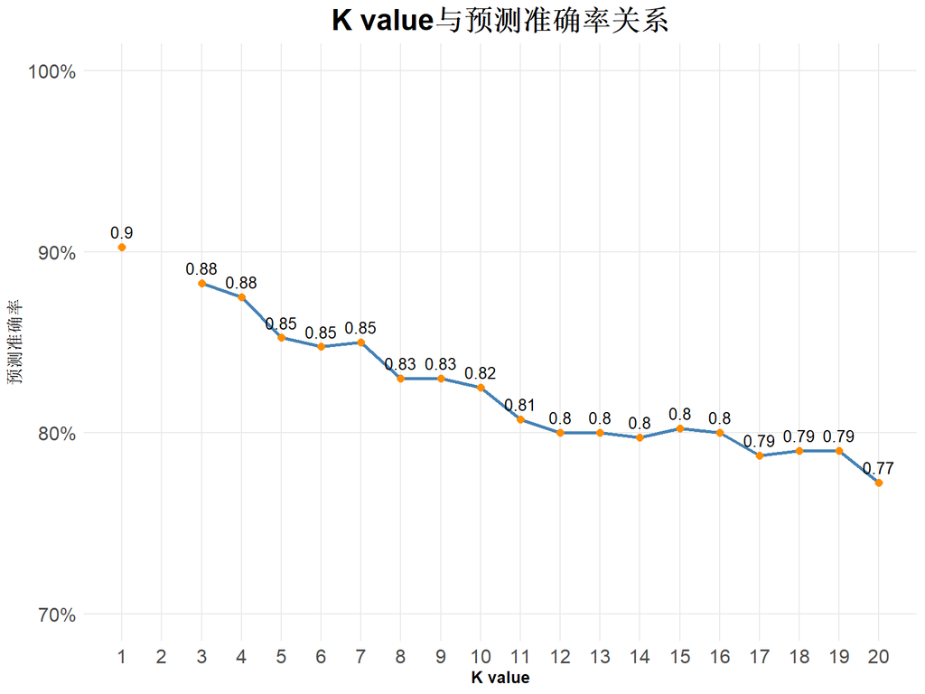

```r
channels_train[is.na(channels_train)] <- colMeans(channels_train, na.rm = TRUE)


k_values <- 1:20  # 你可以根据需要修改k的范围
accuracy <- numeric(length(k_values))
for(i in seq_along(k_values)) {
  pred <- knn(
    train = channels_train,
    test = channels_test,
    cl = channels_train_labels,
    k = k_values[i]
  )
  # 让pred的levels与真实标签一致
  pred <- factor(pred, levels = levels(channels_test_labels))
  accuracy[i] <- mean(pred == channels_test_labels)
}

results <- data.frame(
  k = k_values,
  Accuracy = accuracy
)




# 可视化
ggplot(results, aes(x = k, y = Accuracy)) +
  geom_line(color = "steelblue", linewidth = 1) +
  geom_point(color = "darkorange", size = 2) +
  geom_text(aes(label = round(Accuracy, 2)), vjust = -0.7, size = 3.5, color = "black") +
  scale_x_continuous(breaks = results$k) +
  scale_y_continuous(limits = c(0.7, 1), labels = scales::percent_format(accuracy = 1)) +
  labs(
    title = "K value与预测准确率关系",
    x = "K value",
    y = "预测准确率"
  ) +
  theme_minimal(base_size = 10) +
  theme(
    plot.title = element_text(face = "bold", hjust = 0.5, size = 18),
    axis.title = element_text(face = "bold"),
    axis.text = element_text(size = 12),
    panel.grid.minor = element_blank()
  )
```

#训练模型

```r
channels_pred1 <- knn(
  train = channels_train,
  test = channels_test,
  cl = channels_train_labels,
  k = 2 #根据需要输入K 值
)


head(channels_pred1)
```

```
## [1] 5 5 5 5 4 5
## Levels: 1 2 3 4 5 6
```

```r
#强制设置预测结果的因子 levels 与真实标签一致
channels_pred1 <- factor(channels_pred1, levels = levels(channels_test_labels))
```

#评估模型

```r
# 生成混淆矩阵对象
cm <- confusionMatrix(channels_pred1, channels_test_labels)
cm
```

```
## Confusion Matrix and Statistics
##
##           Reference
## Prediction   1   3   4   5   6
##          1   0   1   0   0   0
##          3   1   0   5   0   0
##          4   1   7  45  10   0
##          5   0   2  11 294   4
##          6   0   0   0   2  16
##
## Overall Statistics
##
##                Accuracy : 0.8897
##                  95% CI : (0.8548, 0.9187)
##     No Information Rate : 0.7669
##     P-Value [Acc > NIR] : 2.673e-10
##
##                   Kappa : 0.7063
##
##  Mcnemar's Test P-Value : NA
##
## Statistics by Class:
##
##                      Class: 1 Class: 3 Class: 4 Class: 5 Class: 6
## Sensitivity          0.000000  0.00000   0.7377   0.9608  0.80000
## Specificity          0.997481  0.98458   0.9467   0.8172  0.99472
## Pos Pred Value       0.000000  0.00000   0.7143   0.9453  0.88889
## Neg Pred Value       0.994975  0.97455   0.9524   0.8636  0.98950
## Prevalence           0.005013  0.02506   0.1529   0.7669  0.05013
## Detection Rate       0.000000  0.00000   0.1128   0.7368  0.04010
## Detection Prevalence 0.002506  0.01504   0.1579   0.7794  0.04511
## Balanced Accuracy    0.498741  0.49229   0.8422   0.8890  0.89736
```

#模型可视化

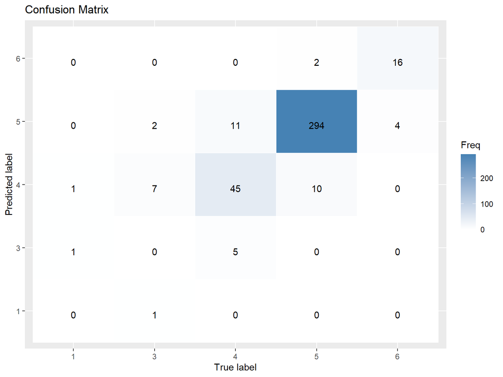

```r
# 转为数据框





cm_table <- as.data.frame(cm$table)
colnames(cm_table) <- c("Prediction", "Reference", "Freq")

# 绘制热力图
(ggplot(data = cm_table, aes(x = Reference, y = Prediction, fill = Freq)) +
  geom_tile(color = "white") +

  scale_fill_gradient(low = "white", high = "steelblue") +
  geom_text(aes(label = Freq), vjust = 1) +
  labs(title = "Confusion Matrix", x = "True label", y = "Predicted label"))
```

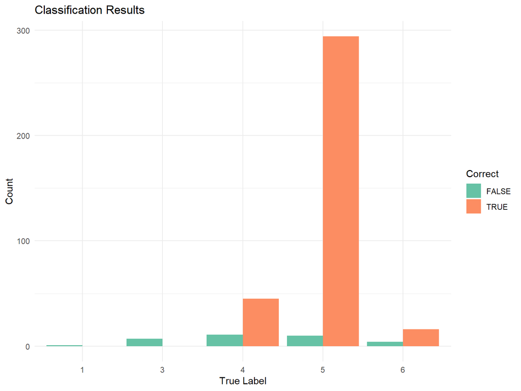

```r
cm_table <- as.data.frame(cm$table)
cm_table$Correct <- cm_table$Prediction == cm_table$Reference






ggplot(cm_table, aes(x=Reference, y=Freq, fill=Correct)) +
  geom_bar(stat="identity", position="dodge") +
  labs(title="Classification Results", x="True Label", y="Count") +
  scale_fill_brewer(palette = "Set2") +
  theme_minimal()
```

#保存模型

```r
knn_model_meta <- list(
  train_data = channels_train,
  train_labels = channels_train_labels,
  k_value = 2,  # 保存关键参数
  normalization_params = list(  # 若有归一化参数需保存
    mean = apply(channels_train, 2, mean),
    sd = apply(channels_train, 2, sd)
  )
)

# 使用压缩格式保存
saveRDS(knn_model_meta, file = "knn_model_meta.rds", compress = "xz")

# 重新加载时
loaded_model <- readRDS("knn_model_meta.rds")
```